# Logrank test

In this notebook we will implement the logrank test, which is a non parametric test that is used to test the equality of two survival functions: $H_0: S_0(t) = S_1(t)$. This test is used also in scenarios where there is right-censoring.

We will generate our data following Weibull distributions. Thw Weibull distribution with shape parameter $a$ and scale parameter $\sigma$ has density given by:

$$f(x) = \frac{a}{\sigma} \left( \frac{x}{\sigma} \right)^{a-1}
\exp\left(-\frac{x}{a} \right)^a$$

The cumulative distribution function is $F(x) = 1-\exp\left(-\frac{x}{\sigma} \right)^a, x>0$

We also generate the censoring times, following an exponential distribution. Right now, we suppose the same rate parameter for both treatment groups (but we could change that and change the censoring).

```r
require(survival)
# number of observations in each group
n0 = 100
n1 = 100
n = n0+n1

# parameters for the weibull distribution
shape0 = 0.3
scale0 = 5
shape1 = 0.5
scale1 = 5

# parameters for the exponential censoring
rate0 = 0.1
rate1 = 0.1

# group 0
alltimes0_unsort = rweibull(n0,shape=shape0,scale=scale0) # censored and uncensored times
censtimes0_unsort = rexp(n0,rate=rate0) # exponential censoring
status0_unsort = as.numeric(alltimes0_unsort <= censtimes0_unsort) # censoring status: 0 if uncensored

Tsort0 = sort(alltimes0_unsort, index.return = TRUE)
alltimes0 = Tsort0$x # sorted times group 0
status0 = status0_unsort[Tsort0$ix] # corresponding censoring status group 0
group0 = rep(0, n0) # list with 0s (group id)

# group 1
alltimes1_unsort = rweibull(n1,shape=shape1,scale=scale1) # censored and uncensored times
censtimes1_unsort = rexp(n1,rate=rate1) # exponential censoring
status1_unsort = as.numeric(alltimes1_unsort <= censtimes1_unsort)

Tsort1 = sort(alltimes1_unsort, index.return = TRUE)
alltimes1 = Tsort1$x # sorted times group 1
status1 = status1_unsort[Tsort1$ix] # corresponding censoring status for the sorted times group 1
group1 = rep(1, n1) # list with 1s (group id)
```

We will construct a dataset with all the times (censored and uncensored), status and group id:

```r
taus_sort = sort(c(alltimes0, alltimes1), index.return = TRUE)
taus = taus_sort$x

status_unsort = c(status0, status1) # all censoring status
status = status_unsort[taus_sort$ix]

groups_unsort = c(group0, group1)
groups = groups_unsort[taus_sort$ix]

data <- data.frame(taus, status, groups)
head(data, 10)
```

|  | taus | status | groups |
| --- | --- | --- | --- |
| 1 | 1.447128e-08 | 1 | 0 |
| 2 | 3.155540e-07 | 1 | 0 |
| 3 | 2.183031e-05 | 1 | 0 |
| 4 | 2.624884e-05 | 1 | 0 |
| 5 | 5.880851e-05 | 1 | 0 |
| 6 | 6.720954e-05 | 1 | 0 |
| 7 | 3.998598e-04 | 1 | 0 |
| 8 | 5.796447e-04 | 1 | 0 |
| 9 | 6.631834e-04 | 1 | 0 |
| 10 | 7.804016e-04 | 1 | 0 |

We can then compute the number of deaths and number at risk for each group at each time $\tau$

```r
m = length(taus)

d0 = c() # uncensored deaths for each time in group 0
d1 = c() # uncensored deaths for each time in group 1
cens0 = c() # censored events at each time in group 0
cens1 = c() # censored events at each time in group 1

for(i in 1:length(taus)){
  val0 = 0
  # number of deaths at each tauj in group 0
  countd0 = sum(as.numeric(alltimes0[status0==1]==taus[i]))
  d0 <- c(d0,countd0)
  # number of censored events at each tauj in group 0
  countc0 = sum(as.numeric(alltimes0[status0==0]==taus[i]))
  cens0 <- c(cens0,countc0)
  # number of deaths at each tauj in group 1
  countd1 = sum(as.numeric(alltimes1[status1==1]==taus[i]))
  d1 <- c(d1,countd1)
  # number of censored events at each tauj in group 1
  countc1 = sum(as.numeric(alltimes1[status1==0]==taus[i]))
  cens1 <- c(cens1,countc1)
}

d = d0+d1 # total number of deaths in each time

m = length(taus)

# computing number at risk

risk0 = rep(n0,m)
risk1 = rep(n1,m)
risk0[2:m] = risk0[2:m] - cumsum(d0+cens0)[1:(m-1)]
risk1[2:m] = risk1[2:m] - cumsum(d1+cens1)[1:(m-1)]
```

We can finally compute the test statistic:

```r
# total number at risk in each time
Y = risk0+risk1 #seq(n,1,by=-1)
# expected number of deaths in group 1
E = sum(d*risk1/Y)
# observed number of deaths in group 1
O = sum(d1)
# variance
V = ((Y - risk1)/(Y-1))*risk1*(d/Y)*(1-d/Y)
# squared test statistic
Z = (O-E)/sqrt(sum(na.omit(V)))
# test statistic that follows (asymptotically) a chi squared with one degree of liberty
Z2 = Z^2
print(Z2)
```

```
[1] 1.432588
```

```r
# P-value: smallest alpha for which H0 is rejected. H0: hazard functions are equal
pchisq(Z2,1,lower.tail = F)
```

```
[1] 0.2313425
```

We can compare with the result obtained by the built-in function from R:

```r
fit <- survdiff(Surv(taus, status)~groups, data=data)
#fit <- survfit(Surv(taus, status) ~ groups, data = data)
fit
```

```
Call:
survdiff(formula = Surv(taus, status) ~ groups, data = data)

           N Observed Expected (O-E)^2/E (O-E)^2/V
groups=0 100       59     65.8     0.699      1.43
groups=1 100       71     64.2     0.716      1.43

 Chisq= 1.4  on 1 degrees of freedom, p= 0.2
```

Particularly, we can compare our results with the ones obtained from the buikt-in function from R:

```r
cat("Our expected group 0:", sum(d*risk0/Y), "\n" )
```

```
Our expected group 0: 65.78009
```

```r
cat("Our expected group 1:", sum(d*risk1/Y), "\n" )
```

```
Our expected group 1: 64.21991
```

```r
cat("Our pvalue:", pchisq(Z2,1,lower.tail = F), ", R's pvalue:", fit$pvalue, "\n" )
```

```
Our pvalue: 0.2313425 , R's pvalue: 0.2311514
```

```r
cat("Our test statistic:", Z2, ", R's test statistic:", fit$chisq, "\n" )
```

```
Our test statistic: 1.432588 , R's test statistic: 1.433762
```

We can see the plot:

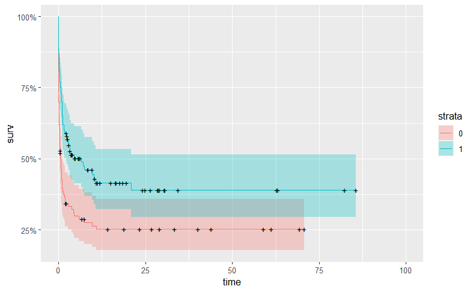

```r
library(ggfortify)
autoplot(fit, xlim= c(0,100))
```

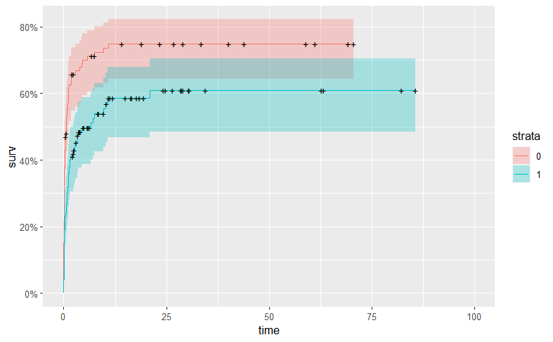

```r
autoplot(survfit(Surv(taus, status) ~ groups, data = data), fun = 'event', xlim= c(0,100))
```